# Congestion Costs in Urban Areas in the U.S.

Carlos Ahumada

March 28, 2019

Traffic jams are a problem that increasingly affect citizens in cities around the world. The costs of being stucked in congestions can range from health (stress) and environmental (pollution) negative consequences, to monetary losses. The Bureau of Transportation Statistics from the United States Department of Transportation published a [dataset](https://www.bts.dot.gov/) that contains information for 101 urban areas in the U.S. on total population, average cost of gasoline, number of rush hours, total hours of delay, number of vehicles commuting per day, and others. With this information, applying a Random Fores algorithm, I am going to try to predict the annual cost per auto of congestion in 2014 taking into account selected variables. 2014 was slected due to its data completeness. Afterwards, other models will be implemented to compare the performance of the Random Forest approach. Finally, I am going to implement a class imbalance solution for the Random Forest model and compare the results with a Naive Bayes approach.

# Preparation

## Libraries

```r
library (randomForest)
library (dplyr)
library (magrittr)
library (caret)
library (ROSE)
library(DMwR)
library (e1071)
library (knitr)
```

## Datset Loading and Cleaning

```r
#Loading Dateset
congestion <- read.csv("C:/Users/carlo/Desktop/congestion.csv", colClasses="character")
str(congestion)
```

```
'data.frame':   3333 obs. of  33 variables:
 $ ï..urban_area                    : chr  "Akron OH" "Akron OH" "Akron OH" "Akron OH" ...
 $ population_group                 : chr  "Med" "Med" "Med" "Med" ...
 $ year                             : chr  "1982" "1983" "1984" "1985" ...
 $ total_population_000             : chr  "515" "515" "515" "515" ...
 $ total_population_rank            : chr  "53" "54" "55" "55" ...
 $ auto_comuters_000                : chr  "205" "208" "209" "211" ...
 $ freeway_daily_miles_000          : chr  "2,745" "3,160" "3,290" "3,255" ...
 $ arterial_daily_miles_000         : chr  "2,120" "2,380" "2,555" "2,395" ...
 $ value_time_000                   : chr  " 7.20 " " 7.43 " " 7.75 " " 8.03 " ...
 $ commercial_value_time_000        : chr  "43.08" "44.23" "46.47" "47.83" ...
 $ average_state_gasoline_cost      : chr  "1.38" "1.32" "1.29" "1.28" ...
 $ average_state_diesel_cost        : chr  "1.34" "1.29" "1.26" "1.24" ...
 $ congested_travel                 : chr  "" "" "" "" ...
 $ congested_system                 : chr  "" "" "" "" ...
```

[output cut: 19 more lines]

# Random Forest imbalanced class

Event though the dataset is small (101 observations), Random Forest can perform well thanks to bootstraping. In order to be able to apply class imbalance solutions, I am going to create a new variable based on the annual cost per auto (high (1) and low (0) cost). This is the dependent variable that I am going to predict using total population, the number of autos commuting, the freeway daily miles, the arterial daily miles, the average state gasoline cost, the average state diesiel cost, the annual excess galons pero auto and the number of rush hours. Please not that some variables like total population contain a 000 notation. This indicates that the number reported is the original figure divided by a thousand.

```r
#Creating outcome variable (high or low annual cost)
congestion$cost_high_low <- ifelse(congestion$cost_per_auto_dollars > mean(congestion$cost_per_auto_dollars),
                                   1, 0)
congestion$cost_high_low <- as.factor(congestion$cost_high_low)
#splitting dataset into train and test
sample_size <- floor(0.50 * nrow(congestion))
set.seed(1628)
congestion_index <- sample(seq_len(nrow(congestion)), size = sample_size)
train <- congestion[congestion_index, ]
test <- congestion[-congestion_index, ]
#Running Model
set.seed(1628)
rf.congestion = randomForest(cost_high_low ~ total_population_000 + auto_comuters_000 +
                               freeway_daily_miles_000 +arterial_daily_miles_000 + average_state_gasoline_cost +
                               average_state_diesel_cost + number_of_rush_hrs,
                               data=train, ntree=100, importance=T)
print(rf.congestion)
```

```
Call:
 randomForest(formula = cost_high_low ~ total_population_000 +      auto_comuters_000 + freeway_daily_miles_000 + arterial_daily_miles_000 +      average_state_gasoline_cost + average_state_diesel_cost +      number_of_rush_hrs, data = train, ntree = 100, importance = T)
               Type of random forest: classification
                     Number of trees: 100
No. of variables tried at each split: 2

        OOB estimate of  error rate: 32%
Confusion matrix:
   0  1 class.error
0 21  8   0.2758621
1  8 13   0.3809524
```

```r
table(congestion$cost_high_low)
```

```
 0  1
56 45
```

```r
#Visualizing the importance of the variables
importance (rf.congestion)
```

```
                                     0          1 MeanDecreaseAccuracy MeanDecreaseGini
total_population_000         4.8227751  3.9512464            5.2732773         5.181298
auto_comuters_000            2.6135007  3.0058807            3.2224873         3.890527
freeway_daily_miles_000      2.5728292  0.7334866            2.2147614         2.379704
arterial_daily_miles_000     5.2776784  2.9138558            6.4452786         4.675636
average_state_gasoline_cost  0.1534902 -1.5664719           -0.7123517         1.243605
average_state_diesel_cost   -2.7110072  1.2797394           -0.5842345         1.515114
number_of_rush_hrs           4.9358747  4.9941976            5.9986616         4.734516
```

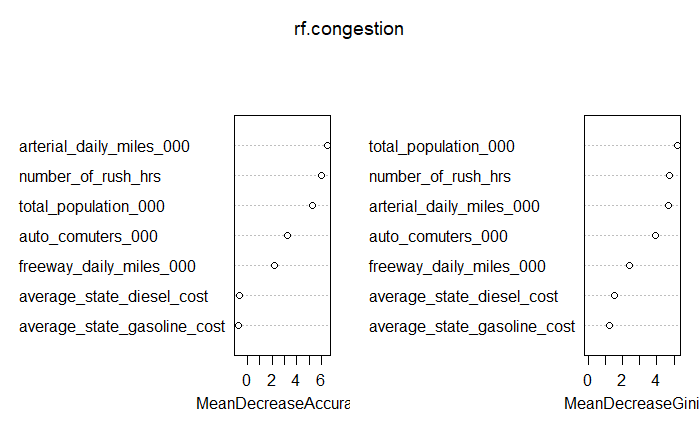

```r
#Visualizing the importance of the variables II
varImpPlot (rf.congestion)
```

In both the table and the plot, it can be seen that the number of arterial daily miles and number of rush hours are the two most important variables in terms of accuracy for the model. If we would get rid of those variables, the accuracy of the model would suffer substantially. On the other hand, total population and the number of rush hours are the most important variables for the Gini index. This means that getting rid of these three variables would affect the Gini impurity used for the calculation of splits in trees.

## calculating the optimal mtry value

```
mtry = 2  OOB error = 21.78%
Searching left ...
Searching right ...
mtry = 3    OOB error = 22.77%
-0.04545455 0.01
```

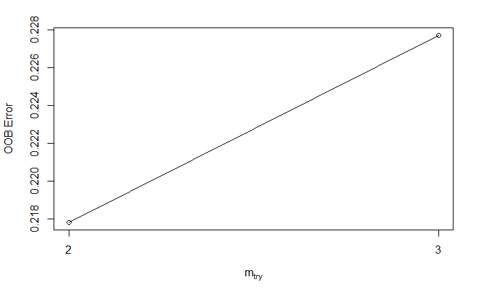

```r
df <- congestion[ ,c("cost_high_low", "total_population_000", "auto_comuters_000", "freeway_daily_miles_000",
                            "arterial_daily_miles_000", "average_state_gasoline_cost", "average_state_diesel_cost", "number_of_rush_hrs")]

mtry <- tuneRF(df[-1], df$cost_high_low, ntreeTry=500,
               stepFactor=1.5,improve=0.01, trace=TRUE, plot=TRUE)
```

```r
best.m <- mtry[mtry[, 2] == min(mtry[, 2]), 1]
print(mtry)
```

```
      mtry  OOBError
2.OOB    2 0.2178218
3.OOB    3 0.2277228
```

```r
print(best.m)
```

```
[1] 2
```

The mtry (Number of variables randomly sampled as candidates at each split) with the lowest OOB error rate is 2. In our first Random Forest model the mtry selected by default was also 2. There is no need to try it with another mtry.

## running model on test set

```r
yhat.rf = predict(rf.congestion ,newdata=test)
confusionMatrix(yhat.rf, test$cost_high_low, mode = "prec_recall", positive="1")
```

```
Confusion Matrix and Statistics

          Reference
Prediction  0  1
         0 24  7
         1  3 17

               Accuracy : 0.8039
                 95% CI : (0.6688, 0.9018)
    No Information Rate : 0.5294
    P-Value [Acc > NIR] : 4.341e-05

                  Kappa : 0.6028
 Mcnemar's Test P-Value : 0.3428

              Precision : 0.8500
                 Recall : 0.7083
                     F1 : 0.7727
             Prevalence : 0.4706
         Detection Rate : 0.3333
   Detection Prevalence : 0.3922
      Balanced Accuracy : 0.7986

       'Positive' Class : 1
```

```r
accuracy.meas(test$cost_high_low, yhat.rf)
```

```
Call:
accuracy.meas(response = test$cost_high_low, predicted = yhat.rf)

Examples are labelled as positive when predicted is greater than 0.5

precision: 0.471
recall: 1.000
F: 0.320
```

# Logistic Regression imbalanced class

```r
congestion_logit = glm(cost_high_low ~ total_population_000 + auto_comuters_000 +
                               freeway_daily_miles_000 +arterial_daily_miles_000 + average_state_gasoline_cost +
                               average_state_diesel_cost + number_of_rush_hrs, family=binomial(link='logit'),data=train)
summary (congestion_logit)
```

```
Call:
glm(formula = cost_high_low ~ total_population_000 + auto_comuters_000 +
    freeway_daily_miles_000 + arterial_daily_miles_000 + average_state_gasoline_cost +
    average_state_diesel_cost + number_of_rush_hrs, family = binomial(link = "logit"),
    data = train)

Deviance Residuals:
    Min       1Q   Median       3Q      Max
-2.1560  -0.4768  -0.2099   0.5203   1.9190

Coefficients:
                              Estimate Std. Error z value Pr(>|z|)
(Intercept)                 -6.274e-01  7.148e+00  -0.088  0.93006
total_population_000        -4.266e-03  3.552e-03  -1.201  0.22981
auto_comuters_000            7.411e-03  8.055e-03   0.920  0.35755
freeway_daily_miles_000     -4.891e-05  1.058e-04  -0.462  0.64404
arterial_daily_miles_000     2.528e-04  2.255e-04   1.121  0.26219
average_state_gasoline_cost -3.376e+00  4.367e+00  -0.773  0.43951
average_state_diesel_cost    1.706e+00  4.111e+00   0.415  0.67815
number_of_rush_hrs           1.176e+00  4.206e-01   2.796  0.00518 **
---
Signif. codes:  0 *** 0.001 ** 0.01 * 0.05 . 0.1   1

(Dispersion parameter for binomial family taken to be 1)

    Null deviance: 68.029  on 49  degrees of freedom
Residual deviance: 34.447  on 42  degrees of freedom
AIC: 50.447

Number of Fisher Scoring iterations: 6
```

```r
predictions = predict (congestion_logit, test, type= "response")
results<- ifelse(predictions >0.5, 1, 0)
results
```

```
  33   66  297  363  396  429  462  528  627  660  693  924  957  990 1056 1089 1122 1188 1254 1353 1419 1452 1518 1551 1716 1914
   0    0    1    0    0    0    1    1    0    1    1    0    1    0    1    0    0    0    0    1    0    0    0    0    1    1
1947 2046 2112 2145 2211 2277 2343 2409 2442 2475 2508 2541 2640 2772 2805 2838 2871 2904 2970 3036 3102 3135 3168 3267 3300
   1    0    0    1    0    1    1    0    0    0    0    1    0    1    1    0    0    1    0    0    0    0    0    0    0
```

```r
results <- as.factor(results)
confusionMatrix(results, test$cost_high_low, mode = "prec_recall", positive="1")
```

```
Confusion Matrix and Statistics

          Reference
Prediction  0  1
         0 27  6
         1  0 18

               Accuracy : 0.8824
                 95% CI : (0.7613, 0.9556)
    No Information Rate : 0.5294
    P-Value [Acc > NIR] : 8.488e-08

                  Kappa : 0.7606
 Mcnemar's Test P-Value : 0.04123

              Precision : 1.0000
                 Recall : 0.7500
                     F1 : 0.8571
             Prevalence : 0.4706
         Detection Rate : 0.3529
   Detection Prevalence : 0.3529
      Balanced Accuracy : 0.8750

       'Positive' Class : 1
```

With a logistic regression, the acurracy of the model increases to 88.24%. In terms of accuracy, the logistic regression model performs better than the Random Forest in this case. Also, it is important to notice that the F1 score increases to .8571, higher than the .77 reported in the Random Forest Model.

# Class Imbalance solution

```r
## Smote : Synthetic Minority Oversampling Technique To Handle Class Imbalancy In Binary Classification
str(train)
```

```
'data.frame':   50 obs. of  34 variables:
 $ urban_area                       : chr  "Columbia SC" "San Diego CA" "San Antonio TX" "Las Vegas-Henderson NV" ...
 $ population_group                 : Factor w/ 4 levels "Lrg","Med","Sml",..: 2 4 1 1 2 1 3 1 4 2 ...
 $ year                             : Factor w/ 1 level "2014": 1 1 1 1 1 1 1 1 1 1 ...
 $ total_population_000             : num  585 3090 1935 1975 845 ...
 $ total_population_rank            : num  72 15 26 24 53 19 89 17 8 71 ...
 $ auto_comuters_000                : num  293 1398 989 982 379 ...
 $ freeway_daily_miles_000          : num  6016 39817 21270 11297 6066 ...
 $ arterial_daily_miles_000         : num  5460 22543 12956 14267 3252 ...
 $ value_time_000                   : num  17.7 17.7 17.7 17.7 17.7 ...
 $ commercial_value_time_000        : num  94 94 94 94 94 ...
 $ average_state_gasoline_cost      : num  3 3.63 3.12 3.43 4.21 3.27 3.63 3.33 3.2 3.33 ...
 $ average_state_diesel_cost        : num  3.43 3.85 3.47 3.71 4.86 3.6 3.85 3.59 3.52 3.59 ...
 $ congested_travel                 : num  19 36 38 40 51 24 21 42 45 23 ...
 $ congested_system                 : num  18 32 34 43 47 20 15 30 35 22 ...
```

[output cut: 20 more lines]

```r
train$year <- as.character(train$year)
train$year <- as.numeric(train$year)
train$urban_area <- as.factor(train$urban_area)
congestion.balanced <- SMOTE(cost_high_low ~., train, perc.over = 100)
table(congestion.balanced$cost_high_low)
```

```
 0  1
42 42
```

# Random Forest with balanced data

```r
#Running Model
set.seed(1628)
rf.congestion2 = randomForest(cost_high_low ~ total_population_000 + auto_comuters_000 +
                               freeway_daily_miles_000 +arterial_daily_miles_000 + average_state_gasoline_cost +
                               average_state_diesel_cost + number_of_rush_hrs,
                               data=congestion.balanced, ntree=100, importance=T)
print(rf.congestion2)
```

```
Call:
 randomForest(formula = cost_high_low ~ total_population_000 +      auto_comuters_000 + freeway_daily_miles_000 + arterial_daily_miles_000 +      average_state_gasoline_cost + average_state_diesel_cost +      number_of_rush_hrs, data = congestion.balanced, ntree = 100,      importance = T)
               Type of random forest: classification
                     Number of trees: 100
No. of variables tried at each split: 2

        OOB estimate of  error rate: 8.33%
Confusion matrix:
   0  1 class.error
0 37  5  0.11904762
1  2 40  0.04761905
```

```r
#Visualizing the importance of the variables
importance (rf.congestion2)
```

```
                                   0        1 MeanDecreaseAccuracy MeanDecreaseGini
total_population_000        5.736691 4.314847             6.362831         6.405197
auto_comuters_000           4.753563 5.221652             7.015969         8.471436
freeway_daily_miles_000     6.035446 4.127447             7.063106         6.796221
arterial_daily_miles_000    5.624829 5.361421             7.350913         8.326488
average_state_gasoline_cost 2.392715 3.086854             3.499380         2.026962
average_state_diesel_cost   2.433868 3.593061             4.336530         2.125928
number_of_rush_hrs          6.406803 7.672347             8.193633         7.286815
```

## Model on Test data after class balance

```r
yhat.rf2 = predict(rf.congestion2 ,newdata=test)
confusionMatrix(yhat.rf2, test$cost_high_low, mode = "prec_recall", positive="1")
```

```
Confusion Matrix and Statistics

          Reference
Prediction  0  1
         0 23  6
         1  4 18

               Accuracy : 0.8039
                 95% CI : (0.6688, 0.9018)
    No Information Rate : 0.5294
    P-Value [Acc > NIR] : 4.341e-05

                  Kappa : 0.6047
 Mcnemar's Test P-Value : 0.7518

              Precision : 0.8182
                 Recall : 0.7500
                     F1 : 0.7826
             Prevalence : 0.4706
         Detection Rate : 0.3529
   Detection Prevalence : 0.4314
      Balanced Accuracy : 0.8009

       'Positive' Class : 1
```